# Lab 5: Rejection sampling and importance sampling

STA 602: Bayesian and Modern Statistics

Oct 17, 2022

**Due:** 12pm, Oct 18, 2022

# Housekeeping

## R/RStudio

You all should have R and RStudio installed on your computers by now. If you do not, first install the latest version of R here: https://cran.rstudio.com (remember to select the right installer for your operating system). Next, install the latest version of RStudio here: https://www.rstudio.com/products/rstudio/download/. Scroll down to the “Installers for Supported Platforms” section and find the right installer for your operating system.

## R Markdown

You are required to use R Markdown to type up this lab report. If you do not already know how to use R markdown, refer to Sakai “Resources/Lab” folder for a very basic R Markdown template as well as a list of resources to help you learn how to use R markdown and LaTex.

## Gradescope

You MUST submit both your .Rmd and .pdf files to Gradescope. Make sure to knit to pdf and not html; ask the TA about knitting to pdf if you cannot figure it out. Be sure to submit under the right assignment entry.

# Getting started

You will need the following R packages. If you do not already have them installed, please do so first using the `install.packages` function.

```r
require(tidyverse)
require(rstan)
```

For this lab, you will need one stan file. Download it from Sakai and make sure to save it in the same folder as the R script or R markdown file you are working from.

# Monte Carlo Simulation

Monte Carlo simulation is a powerful tool to obtain numerical results from repeated random sampling. It enables us to compute integrals by drawing samples from an arbitrary density. Rejection Sampling (RS) and Importance Sampling (IS) are examples of Monte Carlo simulation techniques that are widely used.

In this lab, we will use simulation examples to review and compare the basic ideas of RS and IS, understand what situations are suitable for such techniques and what are the necessary conditions for them to be valid.

# Rejection Sampling

## What is RS?

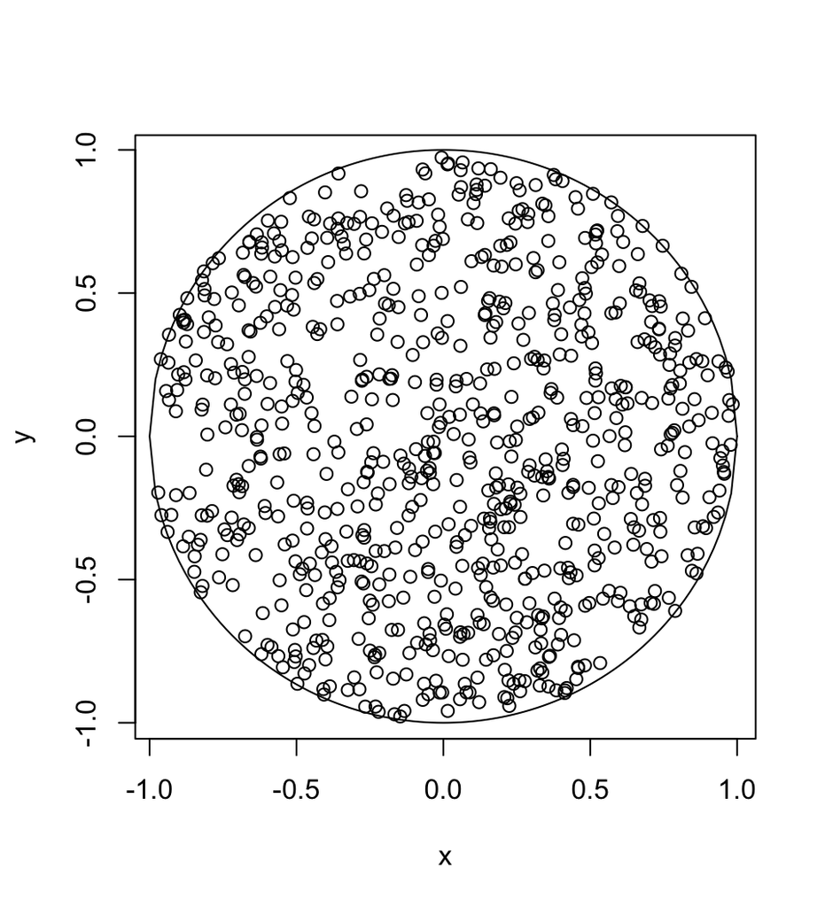

```r
x <- runif(1000,-1,1)
y <- runif(1000,-1,1)
idx <- (x^2 + y^2 < 1)

plot(x[idx], y[idx], xlab="x", ylab="y")
curve((  1 * (1 - x^2)^0.5 ), add=TRUE, from=-1 , to =1)
curve(( -1 * (1 - x^2)^0.5 ), add=TRUE, from=-1 , to =1)
```

## When should we use RS?

- want to sample from a distribution $f(\theta)$ but we only know its kernal, e.g., for posterior distributions;
- want to sample from a truncated pdf but do not want to use inverse cdf methods, e.g., to avoid intractable integrals;
- want to sample from a distribution $f$ which is a hard problem, but we know how to sample from another distribution $g$ (a.k.a. envelop function/ candidate density) which is easy (if certain conditions are met for $g$ and $f$);
- dimension of the problem is reasonably small, usually < 10.

## What are the necessary conditions to use RS?

- able to evaluate the target density $f$, or at least its kernel;
- the candidate density $g$ has heavier tail compared to the target density $f$ at least over the domain we are interested in; or, you should be able to find the finite ceiling constant
  $$\begin{aligned}
  M = \sup_{x \in \mathcal{X}_f} \frac{f(x)}{g(x)} < \infty;
  \end{aligned}$$
- $g$ dominates $f$, i.e., support of $f \subset$ support of $g$.
1. Answer the following questions with explanations.
- Can we use Exponential$(1)$ as the candidate density to draw samples for $N(0,1)$ on the interval $(-3,3)$?
- Can we use $N(0,1)$ as candidate density to draw samples from the standard Cauchy distribution on the interval $(-2,2)$? Hint: Find the $M$ here.
- If we only know the kernel of a uni-variate posterior distribution we are interested in, can we use RS? What if it’s a 100-variate posterior distribution?

## Algorithm

First find a valid ceiling constant $M$, then

- sample $x \sim g$
- simulate $u \sim unif(0,1)$
- accept if
  $$\begin{aligned}
  u \le \frac{f(x)}{Mg(x)}
  \end{aligned}$$
- iterate until enough samples

## Example

Sometimes we only know the kernel of a distribution. We can sample from the kernel and then normalize it. Suppose we want to draw samples from a density function of the following form

$$f(\theta) \propto \sin^2(\pi \theta),
\theta \in [0,1].$$
Let’s first have a look at the shape of this density function.

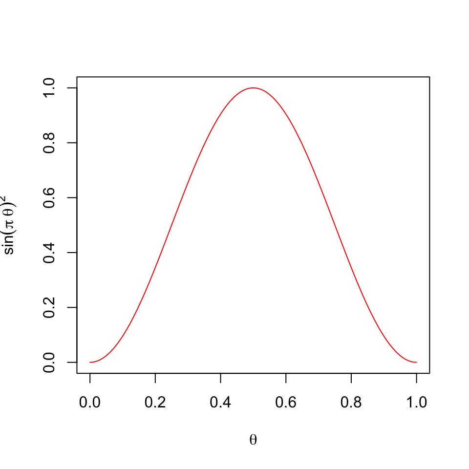

```r
theta <- seq(0,1,length.out = 200)
g_theta <- sin(pi * theta)^2

plot(theta, g_theta, type = "l", col="red",
     xlab = expression(theta), ylab = expression(sin(pi~theta)^2))
```

Notice that the range of the target function is from $0$ to $1$, one simple candidate density we can use is the $Unif(0,1)$ distribution.

2. What are the possible ceiling $M'$ values we can use for this problem? Is it same as the possible values we can use if we were to implement RS on $f(\theta)$ instead of $\sin^2(\pi \theta)$?
3. Make use of the pseudo codes below and implement RS using $Unif(0,1)$ distribution as the candidate density until you have at least $10000$ samples. Report the acceptance rate; plot the density of your samples and the kernel curve, what is the difference?

```r
# target density function
f <- function(x){
  sin(pi*x)^2
}

nsim <- 10000

# acceptance count, total count
ac <- tc <- 0

# to store results
res <- numeric(nsim)

while (ac < nsim){

  # fill in your codes here

}
```

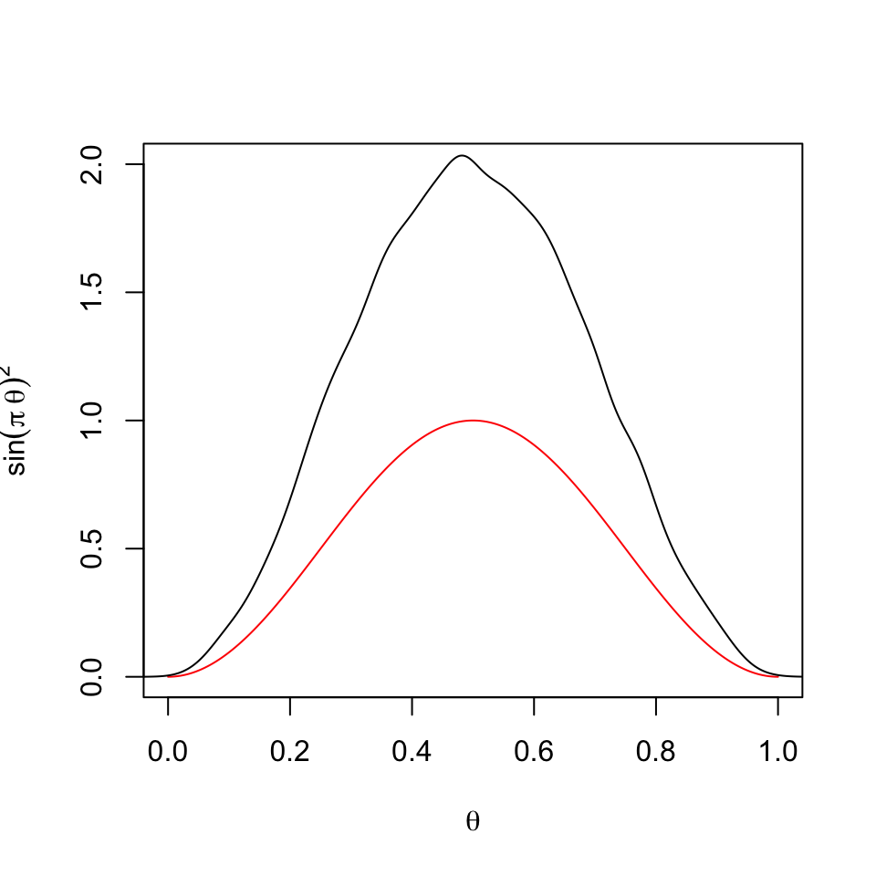

The plot you get should look similar as the one above.

4. Why the density of the samples is very different from the plot of $\sin^2(\pi x)$? What’s the acceptance rate of your sampler? How does the acceptance rate relate to the ceiling constant $M'$ you’ve chosen, and the relative shapes between these two curves? Try different possible $M'$s, repeat the RS algorithm, report the acceptance rates and make the plots similar to the above plot. Discuss your findings. Theoretically speaking, note that if $f$ and $g$ are actual densities (i.e., integrate to $1$), then the acceptance rate $=1/M$ where
   $$\begin{aligned}
   M = \sup_{x \in \mathcal{X}_f} \frac{f(x)}{g(x)},
   \end{aligned}$$
   (Energetic students, what is the difference between $M$ and $M'$? Can you prove this claim?)

This relationship shows to us, the closer our candidate density is to the target density, the smaller the $M$, the higher the acceptance rate and thus the more efficient our sampler is.

5. Think of another candidate density that’s more efficient compared to $Unif(0,1)$. Implement it, plot the density of the samples and the kernel curve, and report the acceptance rate. The acceptance rate here should be higher than that in the $Unif(0,1)$ case. (Hint: think of distribution with similar shape of the target density, e.g., beta distribution with certain parameters).

## Comments on RS

- main drawback of the approach: curse of dimensionality. Notice that as dimension grows, efficiency drops quickly;
- once you find $M$, all the values $>=M$ can be used for RS, but using the smallest possible value would give us the highest acceptance rate;
- always consider implementing your sampler on log scale for numerical stability.

# Importance Sampling

## RS vs IS

With RS, we get a sample from the target density $f$. Samples give us great flexibility – we can basically evaluate any statistics regarding $f$ from the sample. But sometimes we are only interested in computing certain expectations $\mathsf{E}_f[h(X)]$, where $f$ is the target density and $h$ is some function $h: \mathbb{R}^k \to \mathbb{R}$ (e.g., $h(X)=X$ gives us the mean of $f$). While RS is a perfectly valid solution, for this much narrower problem, we can make use of Importance Sampling, which is more efficient.

## What is IS?

The idea is, when we draw samples from the candidate density $g$, most of the time, these are also possible values of the target density $f$, but just appearing in the wrong frequency. So instead of throwing away some of these samples, we can downweight/ upweight them in order to get to the correct frequency under $f$.

$$\begin{aligned}
\int f(x)h(x)dx &= \int \frac{f(x)}{g(x)} g(x) h(x)dx \\
\mathsf{E}_f[h(X)] &= \mathsf{E}_g \left[\frac{f(x)}{g(x)}h(x)
\right].
\end{aligned}$$

Therefore if we are able to draw samples $x_1, \dots, x_n$ from $g$,
$$\begin{aligned}
\frac 1n \sum_{i=1}^n \frac{f(x_i)}{g(x_i)} h(x_i) = \frac 1n
\sum_{i=1}^n w_ih(x_i) \approx \mathsf{E}_f[h(X)].
\end{aligned}$$

6. If we do not know the normalizing constant for both $f$ and $g$, i.e., we only know their kernel $f^*$ and $g^*$, write down the form of the IS estimator. (Hint: see “self-normalizing IS” in lecture 7. )

## Example: Bayesian Sensitivity Analysis

An interesting application of IS in Bayesian statistics is sensitivity analysis of posterior inferences with respect to prior parameter specification.

Suppose we observe data vector $\mathbf{y} \sim f(\mathbf{y} \mid \theta)$. And we assume the parameter $\theta$ follows prior distribution $\pi(\theta \mid \psi_0)$ (note: both $\theta$ and $\psi_0$ here can be vectors). So the posterior distribution of $\theta$ is

$$p(\theta \mid \mathbf{y}, \psi_0)
\propto f(\mathbf{y} \mid \theta) \pi(\theta \mid \psi_0).$$
We can draw samples from this posterior distribution and compute quantities of interests. For example, if we have drawn $\theta_1, \dots, \theta_n$ from the posterior distribution, we can estimate the posterior mean as

$$\mathsf{E}[p(\theta \mid \mathbf{y},
\psi_0)] \approx \frac 1n \sum_{i=1}^n \theta_i.$$

Now suppose we are interested to know what the posterior mean would be if instead of using $\psi_0$, we use $\psi_1 \ne \psi_0$ as prior parameter. How would you calculate it? Of course we can repeat what we did in the first place. First rederive the posterior distribution

$$p(\theta \mid \mathbf{y}, \psi_1)
\propto f(\mathbf{y} \mid \theta) \pi(\theta \mid \psi_1),$$
then draw samples from it and use the sample mean as an estimate.

But leveraging on the concept of IS can save us the efforts of re-sampling. Consider $p(\theta \mid \mathbf{y}, \psi_1)$ as our target density, and $p(\theta \mid \mathbf{y}, \psi_0)$ the candidate density.

7. If we know the full form of $p(\theta \mid \mathbf{y}, \psi_0)$ and $p(\theta \mid \mathbf{y}, \psi_1)$ (i.e., we know the normalizing constant), write down the formula of the IS estimator.
8. Most of the time, we only know the posterior distributions up to a constant. Let $p^*(\theta \mid \mathbf{y}, \psi_0)$ and $p^*(\theta \mid \mathbf{y}, \psi_1)$ denote the kernels of the two posterior distributions, write down the formula of the IS estimator.

Let’s try this idea out with an example we’ve already seen in Lab 2. Recall we were working with rat tumor development data. We assumed the sampling distribution is $Y \sim Binom(N, \theta)$, with $\theta \sim Unif(0,1)$, i.e., $Beta(1,1)$. We looked at two models, one pooled and one unpooled (refer to Lab 2 material if you’ve forgot the details).

For the pooled model, we further did sensitivity analysis to understand impact on the posterior distribution under different prior parameters. For each combination of the prior parameters we wanted to test, we rerun the model and re-drew posterior samples with the help of stan.

Now suppose we are merely interested in understanding changes in posterior means under different prior parameters (and for some reasons we’ve forgot how to calculate the mean of a beta distribution), we can use IS to do this without resampling.

```r
tumors <- read.csv(file = url("http://www.stat.columbia.edu/~gelman/book/data/rats.asc"),
                     skip = 2, header = T, sep = " ")[,c(1,2)]
y <- tumors$y
N <- tumors$N
n <- length(y)

stan_dat <- list(n = n, N = N, y =y, a = 1, b = 1)
fit_pool <- stan('lab-02-pool.stan', data = stan_dat, chains = 2, refresh = 0)
```

```
## Trying to compile a simple C file
```

```r
pool_output <- rstan::extract(fit_pool)
```

9. Use the posterior samples obtained in the variable `pool_output` under the $Beta(1,1)$ prior, estimate the posterior means under different prior assumptions: $a = (1,10,25,100)$, $b=(1,10,25,100)$ with IS (you can make use of the pseudo codes below). Plot your IS estimates of the posterior means with the theoretical values. Answer the following questions:
   - How good are the IS estimates under different prior parameters? Are the IS estimates close to the true theoretical values? Under what choices of the parameters $a$ and $b$ will they tend to be different? (To answer this, you may need to see the IS estimates and the theoretical values under different $a$’s and $b$’s. )
   - In lab 2, we’ve seen that the posterior distribution is sensitive to the choice of prior parameter $a$ in this rat tumor data. Under large $a$’s, are the corresponding posterior distributions (i.e., target distribution) close to the current posterior under $beta(1,1)$ prior (i.e., candidate distribution)? Is the IS effective in this case?
   - For energetic students, try self-normalizing IS, and see what happens!

```r
as <- c(1,10,25,100)
bs <- c(1,10,25,100)

# posterior parameters under the current Beta(1,1) prior
post_a0 <- 1 + sum(y)
post_b0 <- 1 + sum(N) - sum(y)

IS_sensi_mean <- matrix(0, length(as), length(bs))  # IS estimated posterior mean
exp_sensi_mean <- matrix(0, length(as), length(bs))  # theoretical posterior mean

for (i in (1:length(as))){
  for (j in (1:length(bs))){

    # fill in your codes here

  }
}

# plot the theoretical posterior means against the IS estimated posterior means
plot(c(IS_sensi_mean), c(exp_sensi_mean), xlab = "IS", ylab = "Expected")
abline(a = 0, b = 1)  # 45 degree line
```

## Comments on IS

- also not suitable for high dimensional problems;
- subject to the same conditions as RS;
- the closer the candidate density is to the target density, the better the quality of the estimate.

# Grading

Total 10 points. 10 > Excellent; 8 > Good; 6 > Fair; 0 > Poor; NA if no submission.

# Acknowledgement

This lab was created by [Christine Shen](https://scholars.duke.edu/person/yueming.shen).

# References

- [Advanced Statistical Computing](https://bookdown.org/rdpeng/advstatcomp/independent-monte-carlo.html)